# Application for Predicting Swiss Fertility measure on socio-economic indicators

S Nenning

3 November 2018

## Background Information

The applicaton for **Predicting Swiss Fertility measure on socio-economic indicators** is developed with R package **“shiny”**.  
The prediction model is based on standardized fertility measure and socio-economic indicators for each of 47 French-speaking provinces of Switzerland at about 1888, and is available in R as dataset **swiss**. The 5 indicators are Agriculture, Examination (army), Education, Catholic, and Infant Mortality and presented in percentage of total polulation. (*Please refer to R help for further details.*).

The following slides provide an overview and instructions about the application.  
This presentation is available on Github https://snenning.github.io/coursera_ddp/MyAppDDP_W4/MyAppDDP_W4_pres.html.  
Link to R code (ui.R and server.R) for application is https://github.com/snenning/coursera_ddp/tree/gh-pages/MyAppDDP_W4

## Instructions for executing and using application

- Executing application:  
  The application is executed from a html website hosted on Shiny server.  
  Link to application is https://snenning.shinyapps.io/myappddp_w4/.
- Using application for predicting fertility:  
  The application allows for 2 prediction models. First one using indicator *Agriculture* as indicator for predicting fertility. The second one is *Education*. The selection is done with radio buttons located on the left side of application interface.  
  The slider underneath allows for setting a value for the selected indicator for predicting the fertility.  
  Click “Submit” to execute application and update the output.

## Application: Prediction Model

The applicaion is using a **Linear Regression Model** for prediction. Example below for demonstraion purposes is for model1 with *Agriculture* as indicator and value 50 (percentage of population in agriculture) selected for prediction.

*see R code for model and prediction below.*

```r
  # calculate predicton models for indicators
    model1 <- lm(Fertility ~ Agriculture, data = swiss)

    IndicatorInput <- 50 #value retrieved from inputslider, set to 50 for demo
    modelpred1 <- predict(model1, newdata = data.frame(Agriculture = IndicatorInput))
```

## Application output: Plot and prediction

*see R code and plot output below.*

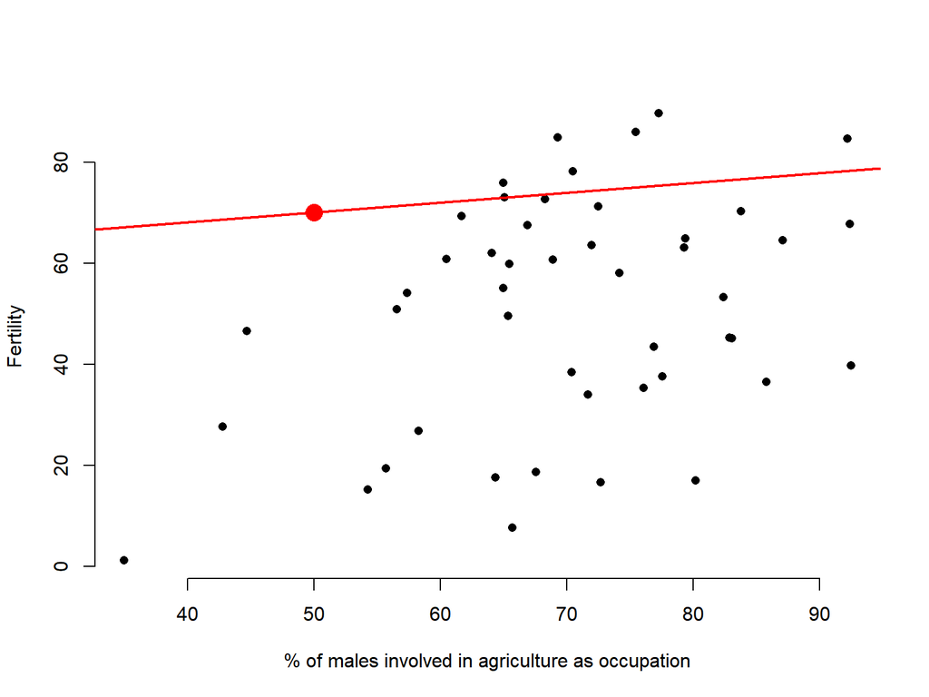

```r
        plot(swiss$Fertility, swiss$Agriculture, xlab = "% of males involved in agriculture as occupation",
             ylab = "Fertility", bty = "n", pch = 16)
        abline(model1, col = "red", lwd = 2)
        points(IndicatorInput , modelpred1, col = "red", pch = 16, cex = 2)
```

The application output below the plot is the “Predicted Fertility for selected population percentage:”; in this example the predicted fertility is 70.01.